# Final Project

Lanxiang Shao

```r
knitr::opts_chunk$set(echo = TRUE)
library(readr)
library(corrplot)
library(dplyr)
library(ggplot2)
library(caret)
library(naivebayes)

dta_bank <- read.csv("Bank Case.csv")
```

# Basic Explanatory Analysis

## 1.

The data is loaded and named above.

## 2.

##### age: numeric, the unit is year, showing how old they are.

##### job: categorical, the occupation of these people.

##### marital: categorical, if they are married or not.

##### education: categorical, education attainment situation.

##### default: categorical, any credit default records.

##### housing: categorical, have house or not.

##### loan: categorical, have loan or not.

##### contact: categorical, contacting methods.

##### month: categorical, which month.

##### day_of_week: categorical, which day of the week.

##### duration: numeric, the unit is second, the call duration.

##### y: categorical, whether join the bank or not.

#### Conclusion: variables age and duration both have outliers. See the code below to prove.

```r
have_outliers = function(data_list){
  mean = mean(data_list)
  sd = sd(data_list)
  outlier = mean + 4 * sd | mean - 4 * sd
  if(sum(outlier > 0)){
    print('have outliers')
    return(TRUE)
    }
    else {print('no outliers')
      return(FALSE)
    }}
```

```r
have_outliers(dta_bank$age)
```

```
## [1] "have outliers"
```

```
## [1] TRUE
```

```r
have_outliers(dta_bank$duration)
```

```
## [1] "have outliers"
```

```
## [1] TRUE
```

## 3.

### Create a corr-plot

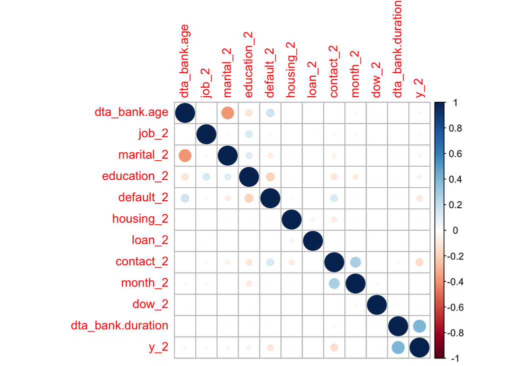

```r
job_2 = as.numeric(as.factor(dta_bank$job))
marital_2 = as.numeric(as.factor(dta_bank$marital))
education_2 = as.numeric(as.factor(dta_bank$education))
default_2 = as.numeric(as.factor(dta_bank$default))
housing_2 = as.numeric(as.factor(dta_bank$housing))
loan_2 = as.numeric(as.factor(dta_bank$loan))
contact_2 = as.numeric(as.factor(dta_bank$contact))
month_2 = as.numeric(as.factor(dta_bank$month))
dow_2 = as.numeric(as.factor(dta_bank$day_of_week))
y_2 = as.numeric(as.factor(dta_bank$y))

dta_bank_2 = data.frame(dta_bank$age,job_2,marital_2,education_2,default_2,housing_2,loan_2,
contact_2,month_2, dow_2,dta_bank$duration, y_2)
M <- cor(dta_bank_2)
corrplot(M, method = "circle")
```

## 4.

```r
dta_bank$y = as.numeric(dta_bank$y)
#(1 for no, 2 for yes)

reg1 = lm(y~.,data=dta_bank)
summary(reg1)
```

```
##
## Call:
## lm(formula = y ~ ., data = dta_bank)
##
## Residuals:
##      Min       1Q   Median       3Q      Max
## -2.27531 -0.11545 -0.04306  0.01903  1.07132
##
## Coefficients: (1 not defined because of singularities)
##                                Estimate Std. Error t value Pr(>|t|)
## (Intercept)                   1.028e+00  1.237e-02  83.133  < 2e-16 ***
## age                           7.978e-04  1.668e-04   4.782 1.74e-06 ***
## jobblue-collar               -2.596e-02  4.995e-03  -5.197 2.03e-07 ***
## jobentrepreneur              -2.669e-02  7.750e-03  -3.444 0.000574 ***
## jobhousemaid                 -4.315e-03  9.226e-03  -0.468 0.640036
## jobmanagement                -1.774e-02  5.835e-03  -3.040 0.002371 **
## jobretired                    6.688e-02  8.158e-03   8.198 2.51e-16 ***
## jobself-employed             -2.307e-02  7.783e-03  -2.963 0.003045 **
## jobservices                  -1.982e-02  5.432e-03  -3.649 0.000263 ***
## jobstudent                    1.203e-01  1.008e-02  11.935  < 2e-16 ***
## jobtechnician                -1.380e-02  4.810e-03  -2.869 0.004119 **
## jobunemployed                 1.853e-02  9.081e-03   2.041 0.041264 *
## jobunknown                    7.523e-03  1.561e-02   0.482 0.629767
## maritalmarried                7.037e-03  4.421e-03   1.592 0.111467
## maritalsingle                 2.247e-02  5.083e-03   4.420 9.89e-06 ***
## maritalunknown               -6.592e-05  3.079e-02  -0.002 0.998292
## educationbasic.6y             5.135e-03  7.204e-03   0.713 0.476033
## educationbasic.9y            -4.368e-03  5.697e-03  -0.767 0.443310
## educationhigh.school         -1.692e-04  5.895e-03  -0.029 0.977096
## educationilliterate           1.171e-01  6.436e-02   1.819 0.068888 .
## educationprofessional.course  5.624e-03  6.629e-03   0.848 0.396185
## educationuniversity.degree    1.689e-02  6.015e-03   2.808 0.004983 **
## educationunknown              2.203e-02  8.094e-03   2.721 0.006504 **
## defaultunknown               -3.884e-02  3.513e-03 -11.057  < 2e-16 ***
## defaultyes                   -5.149e-02  1.573e-01  -0.327 0.743458
## housingunknown                9.568e-04  8.901e-03   0.107 0.914400
## housingyes                    1.379e-03  2.740e-03   0.503 0.614778
## loanunknown                          NA         NA      NA       NA
## loanyes                      -3.908e-03  3.756e-03  -1.041 0.298084
## contacttelephone             -8.121e-02  3.551e-03 -22.870  < 2e-16 ***
## monthaug                     -7.458e-02  6.454e-03 -11.555  < 2e-16 ***
## monthdec                      2.327e-01  2.095e-02  11.108  < 2e-16 ***
## monthjul                     -8.876e-02  6.270e-03 -14.157  < 2e-16 ***
## monthjun                     -1.125e-03  7.073e-03  -0.159 0.873619
## monthmar                      3.036e-01  1.286e-02  23.604  < 2e-16 ***
## monthmay                     -6.867e-02  6.140e-03 -11.183  < 2e-16 ***
## monthnov                     -7.678e-02  6.857e-03 -11.197  < 2e-16 ***
## monthoct                      2.196e-01  1.155e-02  19.011  < 2e-16 ***
## monthsep                      2.178e-01  1.266e-02  17.207  < 2e-16 ***
## day_of_weekmon               -1.007e-02  4.276e-03  -2.356 0.018465 *
## day_of_weekthu                2.683e-03  4.269e-03   0.629 0.529669
## day_of_weektue                6.653e-03  4.336e-03   1.534 0.124929
## day_of_weekwed                7.407e-03  4.328e-03   1.711 0.087014 .
## duration                      4.825e-04  5.196e-06  92.868  < 2e-16 ***
## ---
## Signif. codes:  0 '***' 0.001 '**' 0.01 '*' 0.05 '.' 0.1 ' ' 1
##
## Residual standard error: 0.2724 on 41145 degrees of freedom
## Multiple R-squared:  0.2587, Adjusted R-squared:  0.258
## F-statistic: 341.9 on 42 and 41145 DF,  p-value: < 2.2e-16
```

### a.

y = 1.028e+00 + 7.978e-04 * age + -2.596e-02 * jobblue-collar + -2.669e-02 * jobentrepreneur + … (too many variables, omit some) + 2.683e-03 * day_of_weekthu + 6.653e-03 * day_of_weektue + 7.407e-03 * day_of_weekwed + 4.825e-04 * duration

### b.

#### i.

Best month: March. Best day: Wednesday.

#### ii.

Best income groups:student.

#### iii.

Some variables like the number of the bank branches and the general economic situation of that year will rise the OVB concerns since they are related to other Xs (the variables) and they are also determints of y.

# Predictive Modeling and Tuning

## 1.

Training dataset is the sample of data that we use to fit the model. The actual dataset that we use to train the model. The model sees and learns from this data. The validation set is used to evaluate a given model. We use this data to fine-tune the model hyperparameters. Hence the model occasionally sees this data, but never learns from this. We use the validation data results and update higher level hyperparameters. So the validation set in a way affects a model, but indirectly. Test Dataset is the sample of data used to provide an unbiased evaluation of a final model fit on the training dataset. The test set is generally well curated. It contains carefully sampled data that spans the various classes that the model would face, when used in the real world.

## 2.

I decide to drop the variable duration since the call duration is totally decided by the customers themselves. The bank cannot control the duration. Also, usually at the end of the call, the bank employers would already known the customers’ choice (whether join the bank or not).

```r
dta_bank = dta_bank %>% select(-c(duration))
```

## 3.

Overfitting happens when a model models the training data too well. Overfitting occurs when a model learns the detail and noise in the training data to the extent that it negatively impacts the performance of the model on new data. Underfitting means a model that can neither model the training data nor generalize to new data. An underfit model will be obvious since it will have poor performance on the training data.

## 4.

In the no free lunch theorem, no matter that kind of problems we are going to solve, the computational cost of finding the suitable solutions is the same for each solution method. No solution can save the time, money or any other cost for you.

## 5.

```r
lm1 = lm(y~age+factor(month), data = dta_bank)
summary(lm1)
```

```
##
## Call:
## lm(formula = y ~ age + factor(month), data = dta_bank)
##
## Residuals:
##      Min       1Q   Median       3Q      Max
## -0.51716 -0.10430 -0.08981 -0.06370  0.94018
##
## Coefficients:
##                    Estimate Std. Error t value Pr(>|t|)
## (Intercept)       1.1960515  0.0083511 143.221   <2e-16 ***
## age               0.0002152  0.0001449   1.485    0.138
## factor(month)aug -0.0989919  0.0070793 -13.983   <2e-16 ***
## factor(month)dec  0.2827789  0.0233255  12.123   <2e-16 ***
## factor(month)jul -0.1139863  0.0069330 -16.441   <2e-16 ***
## factor(month)jun -0.0994944  0.0072476 -13.728   <2e-16 ***
## factor(month)mar  0.3006676  0.0142990  21.027   <2e-16 ***
## factor(month)may -0.1401035  0.0064726 -21.646   <2e-16 ***
## factor(month)nov -0.1034286  0.0075944 -13.619   <2e-16 ***
## factor(month)oct  0.2331616  0.0128127  18.198   <2e-16 ***
## factor(month)sep  0.2436841  0.0140543  17.339   <2e-16 ***
## ---
## Signif. codes:  0 '***' 0.001 '**' 0.01 '*' 0.05 '.' 0.1 ' ' 1
##
## Residual standard error: 0.3041 on 41177 degrees of freedom
## Multiple R-squared:  0.07534,    Adjusted R-squared:  0.07512
## F-statistic: 335.5 on 10 and 41177 DF,  p-value: < 2.2e-16
```

y = 1.1960515 + 0.0002152 * age + -0.0989919 * factor(month)aug + 0.2827789 * factor(month)dec + … + 0.2331616 * factor(month)oct + 0.2436841 * factor(month)sep

```r
age2 = (dta_bank$age)^2
age3 = (dta_bank$age)^3
lm2 = lm(y~age+age2+age3+factor(month),data = dta_bank)
summary(lm2)
```

```
##
## Call:
## lm(formula = y ~ age + age2 + age3 + factor(month), data = dta_bank)
##
## Residuals:
##      Min       1Q   Median       3Q      Max
## -0.88433 -0.10753 -0.07989 -0.04982  0.96286
##
## Coefficients:
##                    Estimate Std. Error t value Pr(>|t|)
## (Intercept)       1.841e+00  4.930e-02  37.352  < 2e-16 ***
## age              -3.610e-02  3.263e-03 -11.060  < 2e-16 ***
## age2              5.761e-04  6.892e-05   8.358  < 2e-16 ***
## age3             -2.332e-06  4.633e-07  -5.035  4.8e-07 ***
## factor(month)aug -9.226e-02  7.032e-03 -13.119  < 2e-16 ***
## factor(month)dec  2.481e-01  2.319e-02  10.697  < 2e-16 ***
## factor(month)jul -1.124e-01  6.886e-03 -16.327  < 2e-16 ***
## factor(month)jun -9.232e-02  7.200e-03 -12.821  < 2e-16 ***
## factor(month)mar  2.728e-01  1.425e-02  19.148  < 2e-16 ***
## factor(month)may -1.316e-01  6.434e-03 -20.455  < 2e-16 ***
## factor(month)nov -9.302e-02  7.550e-03 -12.321  < 2e-16 ***
## factor(month)oct  2.033e-01  1.278e-02  15.914  < 2e-16 ***
## factor(month)sep  2.139e-01  1.401e-02  15.272  < 2e-16 ***
## ---
## Signif. codes:  0 '***' 0.001 '**' 0.01 '*' 0.05 '.' 0.1 ' ' 1
##
## Residual standard error: 0.3018 on 41175 degrees of freedom
## Multiple R-squared:  0.08906,    Adjusted R-squared:  0.0888
## F-statistic: 335.5 on 12 and 41175 DF,  p-value: < 2.2e-16
```

y = 1.841e+00 + -3.610e-02 * age + 5.761e-04 * age^2 + -2.332e-06 * age^3 + … + 2.033e-01 * factor(month)oct + 2.139e-01 * factor(month)sep

```r
lm3 = lm(y~., data = dta_bank)
summary(lm3)
```

```
##
## Call:
## lm(formula = y ~ ., data = dta_bank)
##
## Residuals:
##      Min       1Q   Median       3Q      Max
## -0.64287 -0.12109 -0.08726 -0.02863  1.05723
##
## Coefficients: (1 not defined because of singularities)
##                                Estimate Std. Error t value Pr(>|t|)
## (Intercept)                   1.167e+00  1.350e-02  86.442  < 2e-16 ***
## age                           8.316e-04  1.835e-04   4.532 5.86e-06 ***
## jobblue-collar               -2.293e-02  5.493e-03  -4.174 3.00e-05 ***
## jobentrepreneur              -2.282e-02  8.523e-03  -2.677 0.007423 **
## jobhousemaid                 -6.812e-03  1.015e-02  -0.671 0.501998
## jobmanagement                -1.595e-02  6.417e-03  -2.486 0.012931 *
## jobretired                    7.291e-02  8.972e-03   8.127 4.53e-16 ***
## jobself-employed             -1.762e-02  8.560e-03  -2.058 0.039599 *
## jobservices                  -1.997e-02  5.974e-03  -3.343 0.000828 ***
## jobstudent                    1.293e-01  1.109e-02  11.663  < 2e-16 ***
## jobtechnician                -1.425e-02  5.290e-03  -2.694 0.007061 **
## jobunemployed                 1.592e-02  9.987e-03   1.594 0.110963
## jobunknown                   -2.688e-05  1.716e-02  -0.002 0.998750
## maritalmarried                9.484e-03  4.862e-03   1.951 0.051120 .
## maritalsingle                 2.574e-02  5.590e-03   4.604 4.15e-06 ***
## maritalunknown                2.932e-02  3.386e-02   0.866 0.386562
## educationbasic.6y             4.434e-03  7.923e-03   0.560 0.575743
## educationbasic.9y            -6.900e-03  6.266e-03  -1.101 0.270826
## educationhigh.school         -1.503e-03  6.483e-03  -0.232 0.816712
## educationilliterate           1.210e-01  7.079e-02   1.710 0.087313 .
## educationprofessional.course  2.240e-03  7.290e-03   0.307 0.758674
## educationuniversity.degree    1.327e-02  6.615e-03   2.006 0.044862 *
## educationunknown              2.065e-02  8.901e-03   2.320 0.020344 *
## defaultunknown               -4.188e-02  3.864e-03 -10.841  < 2e-16 ***
## defaultyes                   -1.171e-01  1.730e-01  -0.676 0.498738
## housingunknown               -4.191e-03  9.789e-03  -0.428 0.668548
## housingyes                   -1.084e-03  3.013e-03  -0.360 0.718949
## loanunknown                          NA         NA      NA       NA
## loanyes                      -4.002e-03  4.131e-03  -0.969 0.332589
## contacttelephone             -9.006e-02  3.904e-03 -23.069  < 2e-16 ***
## monthaug                     -1.036e-01  7.090e-03 -14.616  < 2e-16 ***
## monthdec                      2.578e-01  2.304e-02  11.189  < 2e-16 ***
## monthjul                     -9.801e-02  6.895e-03 -14.214  < 2e-16 ***
## monthjun                     -1.868e-02  7.776e-03  -2.403 0.016269 *
## monthmar                      2.806e-01  1.414e-02  19.836  < 2e-16 ***
## monthmay                     -7.989e-02  6.752e-03 -11.833  < 2e-16 ***
## monthnov                     -9.972e-02  7.536e-03 -13.232  < 2e-16 ***
## monthoct                      2.166e-01  1.270e-02  17.055  < 2e-16 ***
## monthsep                      2.191e-01  1.392e-02  15.740  < 2e-16 ***
## day_of_weekmon               -1.351e-02  4.702e-03  -2.874 0.004058 **
## day_of_weekthu                8.190e-03  4.694e-03   1.745 0.081056 .
## day_of_weektue                1.090e-02  4.768e-03   2.286 0.022255 *
## day_of_weekwed                1.404e-02  4.759e-03   2.949 0.003188 **
## ---
## Signif. codes:  0 '***' 0.001 '**' 0.01 '*' 0.05 '.' 0.1 ' ' 1
##
## Residual standard error: 0.2995 on 41146 degrees of freedom
## Multiple R-squared:  0.1034, Adjusted R-squared:  0.1025
## F-statistic: 115.7 on 41 and 41146 DF,  p-value: < 2.2e-16
```

y = 1.167e+00 + 8.316e-04 * age - 2.293e-02 * jobblue-collar - 2.282e-02 * jobentrepreneur + … + 1.090e-02 * day_of_weektue + 1.404e-02 * day_of_weekwed

```r
lm4 = lm(y~.^2, data = dta_bank)
summary(lm4)
```

```
##
## Call:
## lm(formula = y ~ .^2, data = dta_bank)
##
## Residuals:
##      Min       1Q   Median       3Q      Max
## -0.84717 -0.10967 -0.06524 -0.02558  1.11740
##
## Coefficients: (101 not defined because of singularities)
##                                                 Estimate Std. Error
## (Intercept)                                    9.962e-01  8.118e-02
## age                                            1.821e-03  1.235e-03
## jobblue-collar                                 7.550e-03  5.809e-02
## jobentrepreneur                               -9.690e-02  7.977e-02
## jobhousemaid                                   3.021e-02  9.566e-02
## jobmanagement                                 -1.349e-01  7.024e-02
## jobretired                                    -4.406e-01  8.415e-02
## jobself-employed                               2.927e-02  8.193e-02
## jobservices                                    1.289e-02  6.497e-02
## jobstudent                                     3.318e-01  1.519e-01
## jobtechnician                                  6.360e-02  6.897e-02
## jobunemployed                                  1.080e-01  9.261e-02
## jobunknown                                    -4.471e-02  1.699e-01
## maritalmarried                                 3.396e-02  4.034e-02
## maritalsingle                                  1.057e-01  4.673e-02
## maritalunknown                                 1.094e-01  4.787e-01
## educationbasic.6y                              3.212e-02  7.952e-02
## educationbasic.9y                              4.651e-03  6.219e-02
## educationhigh.school                           7.572e-02  6.337e-02
## educationilliterate                            1.088e+00  2.637e+00
## educationprofessional.course                   7.611e-02  6.909e-02
## educationuniversity.degree                     1.750e-01  6.393e-02
## educationunknown                               3.683e-02  7.912e-02
## defaultunknown                                -4.463e-02  3.625e-02
## defaultyes                                    -6.175e-02  9.919e-01
## housingunknown                                -7.576e-02  9.015e-02
## housingyes                                    -1.930e-02  2.695e-02
## loanunknown                                           NA         NA
## loanyes                                       -6.147e-03  3.692e-02
## contacttelephone                               4.316e-03  3.941e-02
```

[output cut: 1522 more lines]

```
## monthaug:day_of_weekwed                        -5.104 3.34e-07 ***
## monthdec:day_of_weekwed                         0.775 0.438607
## monthjul:day_of_weekwed                        -6.615 3.77e-11 ***
## monthjun:day_of_weekwed                        -4.581 4.63e-06 ***
## monthmar:day_of_weekwed                        -0.895 0.370736
## monthmay:day_of_weekwed                        -6.002 1.96e-09 ***
## monthnov:day_of_weekwed                        -5.566 2.62e-08 ***
## monthoct:day_of_weekwed                        -4.569 4.92e-06 ***
## monthsep:day_of_weekwed                        -0.281 0.778847
## ---
## Signif. codes:  0 '***' 0.001 '**' 0.01 '*' 0.05 '.' 0.1 ' ' 1
##
## Residual standard error: 0.2926 on 40509 degrees of freedom
## Multiple R-squared:  0.1574, Adjusted R-squared:  0.1433
## F-statistic: 11.16 on 678 and 40509 DF,  p-value: < 2.2e-16
```

y = 9.962e-01 + 1.821e-03 * age + 7.550e-03 * jobblue-collar + -9.690e-02 * jobentrepreneur + … + 3.215e-02 * jobself-employed:defaultunknown

### a.

The lm4 overfits more since it puts too much infomation in the model.

### b.

the lm1 is underfitting more since the variables it uses are not that enough.

### c.

```r
N = nrow(dta_bank)
training_index = sample(N)[1:round(0.6*N)]
dta_bank_training = dta_bank[training_index,]
dta_bank_validating = dta_bank[-training_index, ][1:round(0.2*N),]
dta_bank_test = dta_bank[-training_index, ][(round(0.2*N)+1):round(0.4*N),]

data_new = dta_bank_test[1:11]

pre_1 = predict(lm1, data_new)
cor(dta_bank_test$y, pre_1)
```

```
## [1] 0.2560352
```

```r
pre_3 = predict(lm3, data_new)
cor(dta_bank_test$y, pre_3)
```

```
## [1] 0.3069523
```

```r
pre_4 = predict(lm4, data_new)
cor(dta_bank_test$y, pre_4)
```

```
## [1] 0.3928571
```

```r
#age^2 (age2) and age^3 (age3) are added in this regression, so make a new dataset with variable age2 and age3.
dta_bank_lm2 = dta_bank %>% mutate(age2,age3)
N_lm2 = nrow(dta_bank_lm2)
training_index_lm2 = sample(N_lm2)[1:round(0.6*N_lm2)]
dta_bank_training_lm2 = dta_bank_lm2[training_index_lm2,]
dta_bank_validating_lm2 = dta_bank_lm2[-training_index_lm2, ][1:round(0.2*N_lm2),]
dta_bank_test_lm2 = dta_bank_lm2[-training_index_lm2, ][(round(0.2*N_lm2)+1):round(0.4*N_lm2),]

data_new_lm2 = dta_bank_test_lm2

pre_2 = predict(lm2, data_new_lm2)
cor(dta_bank_test_lm2$y, pre_2)
```

```
## [1] 0.2751729
```

No, because it may fit into some unrelated and unimportant variables in the training data. That will not help our predictions a lot and that model does not have the best predictive power. The model lm4 has the highest accuracy, but lm4 is overfitting compared to lm3.

### d.

```r
#probability that the answer will be 'no'
print(mean(dta_bank$y == 1))
```

```
## [1] 0.8873458
```

Yes. For both the accuracy of the training dataset and the test dataset, if two accuracy rates are close or even lower than the probabiliry of saying ‘no’ to all the observations in our original dta_bank data (that is close or lower than 0.887), then it means the model probably has the problem of underfitting.

### e.

We should use the training dataset of lm3 to run these regressions. After running these regressions, we can use the validating dataset to see if we meet the problem of overfitting or underfitting. Then, we can use the test dataset to evaluate the predictive power of the models. If we cannot get a good result, we should start over, like adjusting the dataset division.

# Improving the predictive power

## 1.

They do not look linear. Predicted y is numeric values ranging from 1(no)-2(yes) instead of only 1 and 2.

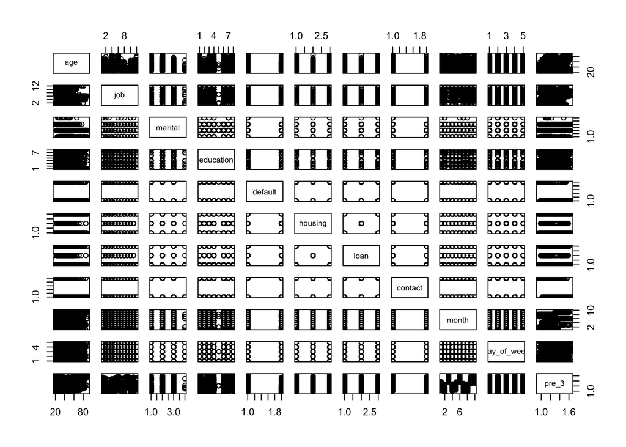

```r
#pre_3 is the predicted y value
pre3 = as.data.frame(pre_3)
data_new$pre_3 = pre3$pre_3
pairs(data_new[,-11])
```

## 2.

```r
#normalize function
Normalize = function(x){return ((x - min(x)) / (max(x) - min(x)))}

#prepare suitable dataset, drop variable duration
dta_bank_2 = dta_bank_2 %>% select(-c(dta_bank.duration))

#renaming y as a factor with proper labels
dta_bank_2$y_2 = factor(x = dta_bank_2$y_2,
                      levels = c("1", "2"),
                      labels = c("NO", "YES"))
#build labels
Label = dta_bank_2[,11]

#create training, validate and test data
num = nrow(dta_bank_2)
training_index_num = sample(num)[1:round(0.6*num)]

dta_bank_training_num = dta_bank_2[training_index,]
dta_bank_validating_num = dta_bank_2[-training_index, ][1:round(0.2*num),]
dta_bank_test_num = dta_bank_2[-training_index, ][(round(0.2*num)+1):round(0.4*num),]

#create labels for data
training_labels_num = Label[training_index]
validating_labels_num = Label[-training_index][1:round(0.2*num)]
test_labels_num = Label[-training_index][(round(0.2*num)+1):round(0.4*num)]

#NaiveBayes
NBclassifier  = e1071::naiveBayes(y_2~., data = dta_bank_validating_num)
NB_prediction = predict(NBclassifier, newdata = dta_bank_validating_num[, -11], type = 'class')
NB_conf_mat  = gmodels::CrossTable(x = validating_labels_num,
                                      y = NB_prediction,
                                      prop.chisq = T)
```

```
##
##
##    Cell Contents
## |-------------------------|
## |                       N |
## |         N / Table Total |
## |-------------------------|
##
##
## Total Observations in Table:  8238
##
##
##                       | NB_prediction
## validating_labels_num |        NO | Row Total |
## ----------------------|-----------|-----------|
##                    NO |      7854 |      7854 |
##                       |     0.953 |           |
## ----------------------|-----------|-----------|
##                   YES |       384 |       384 |
##                       |     0.047 |           |
## ----------------------|-----------|-----------|
##          Column Total |      8238 |      8238 |
## ----------------------|-----------|-----------|
##
##
```

```r
confusionMatrix(NB_prediction,validating_labels_num)
```

```
## Confusion Matrix and Statistics
##
##           Reference
## Prediction   NO  YES
##        NO  7854  384
##        YES    0    0
##
##                Accuracy : 0.9534
##                  95% CI : (0.9486, 0.9578)
##     No Information Rate : 0.9534
##     P-Value [Acc > NIR] : 0.5136
##
##                   Kappa : 0
##
##  Mcnemar's Test P-Value : <2e-16
##
##             Sensitivity : 1.0000
##             Specificity : 0.0000
##          Pos Pred Value : 0.9534
##          Neg Pred Value :    NaN
##              Prevalence : 0.9534
##          Detection Rate : 0.9534
##    Detection Prevalence : 1.0000
##       Balanced Accuracy : 0.5000
##
##        'Positive' Class : NO
##
```

```r
#KNN
#normalize dataset
dta_bank_N = as.data.frame(lapply(dta_bank_2[,1:10], Normalize))

#create training, validate and test data
num = nrow(dta_bank_N)
training_index_num = sample(num)[1:round(0.6*num)]

dta_bank_training_num = dta_bank_N[training_index,]
dta_bank_validating_num = dta_bank_N[-training_index, ][1:round(0.2*num),]
dta_bank_test_num = dta_bank_N[-training_index, ][(round(0.2*num)+1):round(0.4*num),]

#create labels for data
training_labels_num = Label[training_index]
validating_labels_num = Label[-training_index][1:round(0.2*num)]
test_labels_num = Label[-training_index][(round(0.2*num)+1):round(0.4*num)]
#training model
KNN_prediction = class::knn(train = dta_bank_training_num[,-11],
                            cl    = training_labels_num,
                            test  = dta_bank_validating_num[,-11],
                            k     = 5)

#evaluating performance
KNN_conf_mat  = gmodels::CrossTable(x = validating_labels_num,
                                    y = KNN_prediction,
                                    prop.chisq = T)
```

```
##
##
##    Cell Contents
## |-------------------------|
## |                       N |
## | Chi-square contribution |
## |           N / Row Total |
## |           N / Col Total |
## |         N / Table Total |
## |-------------------------|
##
##
## Total Observations in Table:  8238
##
##
##                       | KNN_prediction
## validating_labels_num |        NO |       YES | Row Total |
## ----------------------|-----------|-----------|-----------|
##                    NO |      7818 |        36 |      7854 |
##                       |     0.000 |     0.001 |           |
##                       |     0.995 |     0.005 |     0.953 |
##                       |     0.953 |     0.947 |           |
##                       |     0.949 |     0.004 |           |
## ----------------------|-----------|-----------|-----------|
##                   YES |       382 |         2 |       384 |
##                       |     0.000 |     0.030 |           |
##                       |     0.995 |     0.005 |     0.047 |
##                       |     0.047 |     0.053 |           |
##                       |     0.046 |     0.000 |           |
## ----------------------|-----------|-----------|-----------|
##          Column Total |      8200 |        38 |      8238 |
##                       |     0.995 |     0.005 |           |
## ----------------------|-----------|-----------|-----------|
##
##
```

```r
confusionMatrix(data = KNN_prediction, reference = validating_labels_num)
```

```
## Confusion Matrix and Statistics
##
##           Reference
## Prediction   NO  YES
##        NO  7818  382
##        YES   36    2
##
##                Accuracy : 0.9493
##                  95% CI : (0.9443, 0.9539)
##     No Information Rate : 0.9534
##     P-Value [Acc > NIR] : 0.963
##
##                   Kappa : 0.0011
##
##  Mcnemar's Test P-Value : <2e-16
##
##             Sensitivity : 0.995416
##             Specificity : 0.005208
##          Pos Pred Value : 0.953415
##          Neg Pred Value : 0.052632
##              Prevalence : 0.953387
##          Detection Rate : 0.949017
##    Detection Prevalence : 0.995387
##       Balanced Accuracy : 0.500312
##
##        'Positive' Class : NO
##
```

## 3.

# Causal Questions

## 1.

### a.

In a causal analysis, the independent variables are considered to be causes of the dependent variable. It is pretty clear to see the role of causes and effects. We look at our evidence and draw the conclusion that X causes Y. It is easilly understood. In marketing, sometimes we only want to know the correlation relationship, like they are positively related or negatively related. The degree or the quantity of the future effects are hard to predict accurately.

### b.

The model does not get the best linear unbiased estimator (BLUE). Bias means that the expected value of the estimator is not equal to the population parameter. Intuitively in a regression analysis, this would mean that the estimate of one of the parameters is too high or too low. OVB usually happen under this kind of situation.

## 2.

In dataset dta_bank, variables job and marital will be interesting to analyze from a casual point of view. Specifically speaking, the bank just need to know which jobs are more willing to join the bank and which jobs are negatively related to join the bank. The bank just needs roughly to know the positive and negative relationship. Also, people’s jobs usually change over time. If people’s job changes in future, the current job is hard to support the prediction for the future judgement. This is the same for marital. People’s marital status also changes over time. This is a personal choice which is cannot controled by the bank. Therefore, just knowing the rough positive or negative relationship and the coefficient is enough.

### 3.

Omitted variables are related to the Xs and also are determinant of Y. For the variable job, OVB will arise if we do not conclude the working years. Usually, people working in a short time cannot accumulate much wealth, which discourage them from joining the bank. For instance, they do not have much money to deposit or buy the bank financial products. For the variable marital, we’d better include variables like the number of the children, the size of the household, or if their companion joins the bank. Couples with children are more willing to join the bank, since these families seek for a long-term insurance and would like to consider for their children (like children’s future college spending). Joining the bank would be a good choice for them to manage their money. Also, if your husband/wife joinds the bank, you will be more likely to join the bank since you can easily see the benefits of joining the bank.